# HW5 Kelly “Scott” Sims

## **Question 8.1**

Describe a situation or problem from your job, everyday life, current events, etc., for which a linear regression model would be appropriate. List some (up to 5) predictors that you might use.

> I work in the oil industry in which we utilize advanced downhole logging and drilling tools to drill an oil well and hit the payzone. All of these tools have to go through various levels of servicing and parts replacement depending on the amount of abuse they’ve taken downhole throughout its lifetime since the last servicing. There’s various instrumentation on these tools to record the “abuse”. There’s internal thermometers, accelerometers, magnetometers, pressure sensors, etc. A simple regression model could help predict how many hours a tool can be utilized without servicing before it fails. Predictors could be:
1. The amount of time spent at various g-shock severity levels (binned like a histogram)
2. The amount of time spent at various torque levels (binned like a histogram)
3. The amount of time spent at various temperature levels (binned like a histogram)
4. The amount of time spent at various compression levels - the amount of weight pushed down on the tools (binned like a histogram)
5. The total amount of time elapsed since the last servicing
6. The amount of time spenat at various pressure levels (binned like a histogram)

## **Question 8.2**

Using crime data from http://www.statsci.org/data/general/uscrime.txt (file uscrime.txt, description at http://www.statsci.org/data/general/uscrime.html ), use regression (a useful R function is lm or glm) to predict the observed crime rate in a city with the following data: M = 14.0 So = 0 Ed = 10.0 Po1 = 12.0 Po2 = 15.5 LF = 0.640 M.F = 94.0 Pop = 150 NW = 1.1 U1 = 0.120 U2 = 3.6 Wealth = 3200 Ineq = 20.1 Prob = 0.04 Time = 39.0

```r
library(ggplot2)
library(GGally)
#load the data
data = read.table('uscrime.txt', header = TRUE, stringsAsFactors = FALSE)
#lm(data$Crime~. , data = data)
```

First we will compare each independent variable with the target variable, crime, in search of any correlation.

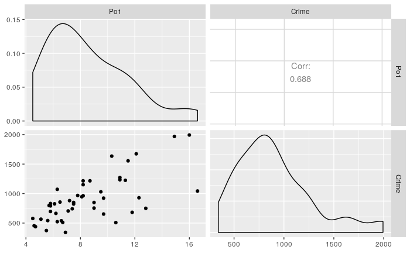

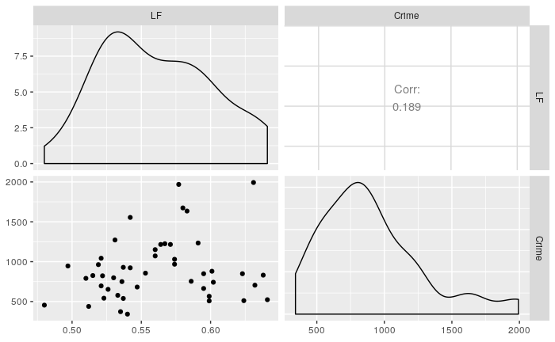

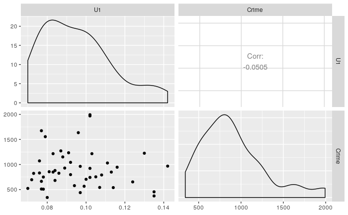

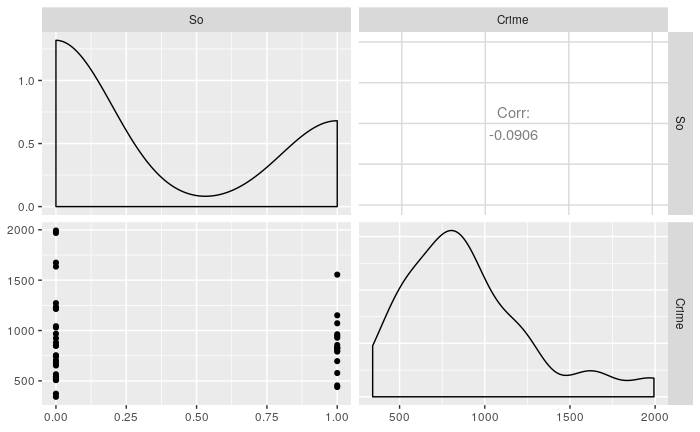

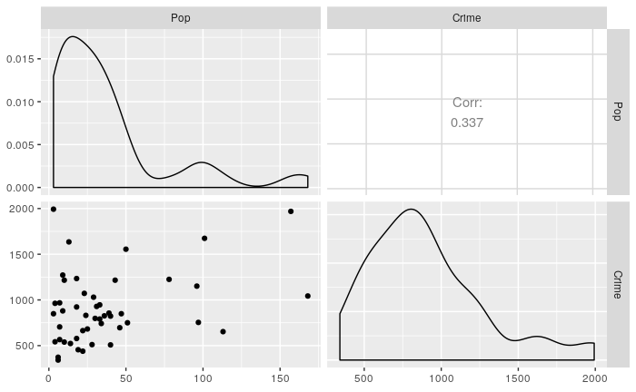

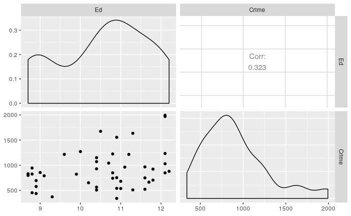

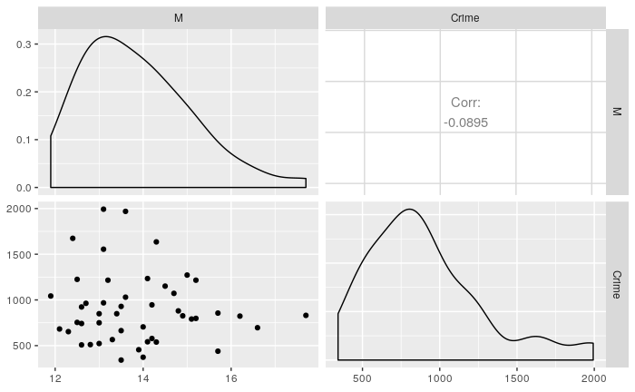

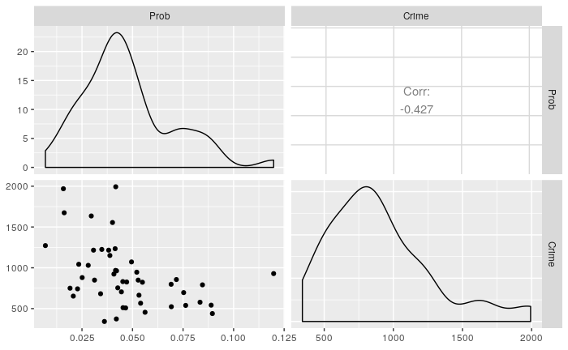

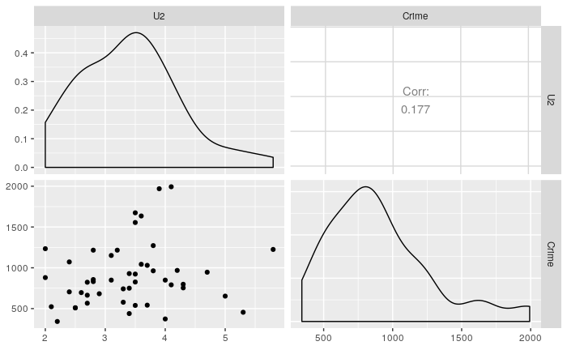

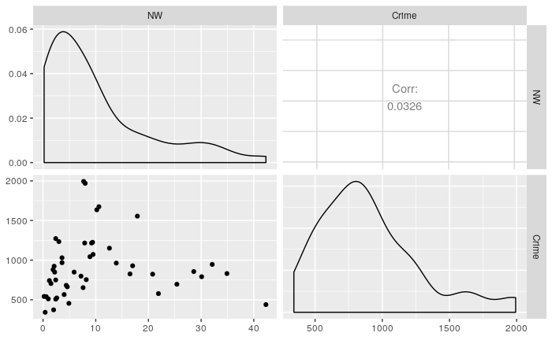

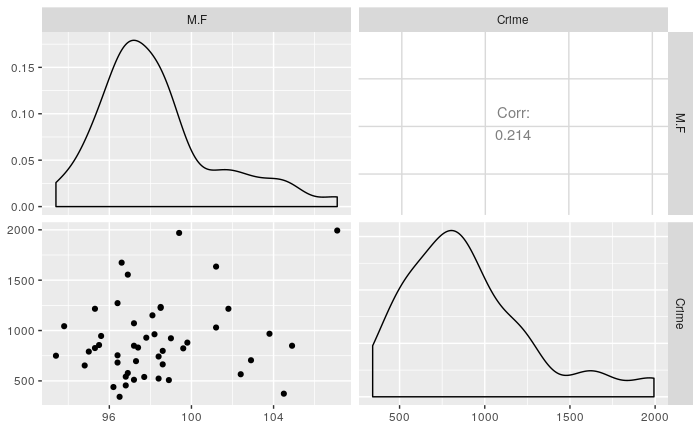

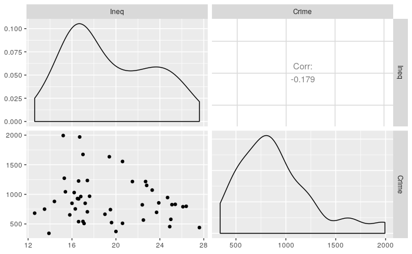

[3 more figures not shown]

```r
for(i in seq(1,15)){
pm = ggpairs(data=data,
             columns= c(i,16),

             )
print(pm)
}
```

Surprisingly there’s a high positive correlation between Po2 and Po1 with Crime. Po1 is per capital expenditure on police protection in 1959 and Po2 is representative of 1960. This is interpreted that there’s a correlation that when police expenditure increases, so does crime. Another surpirsing note is that there is a relatively high negative correlation between prob and crime. This means that if there’s a higher probability of going to jail, crime rate drops. Finally, there’s also a decent correlation between wealth and crime. With increasing wealth comes increasing crime. Next, let’s perform the same analysis, but on the log of the data to find any other hidden correlations.

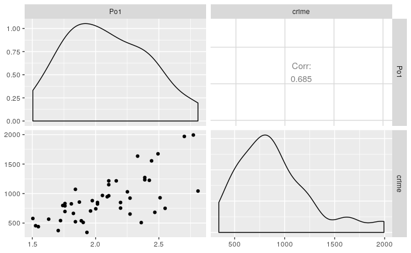

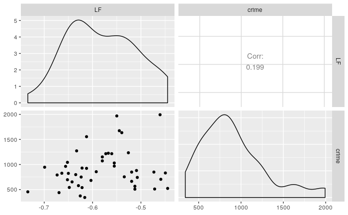

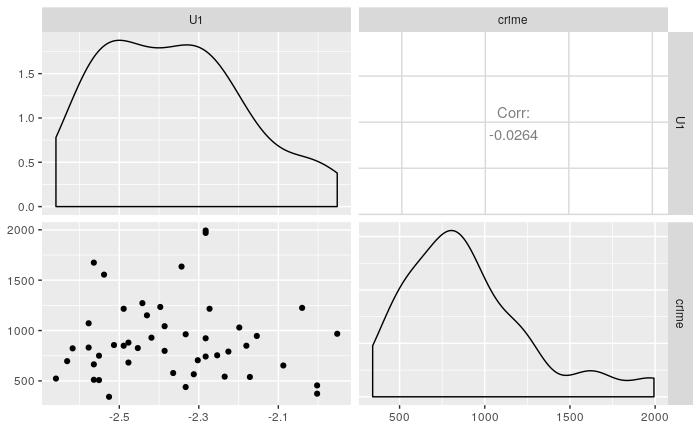

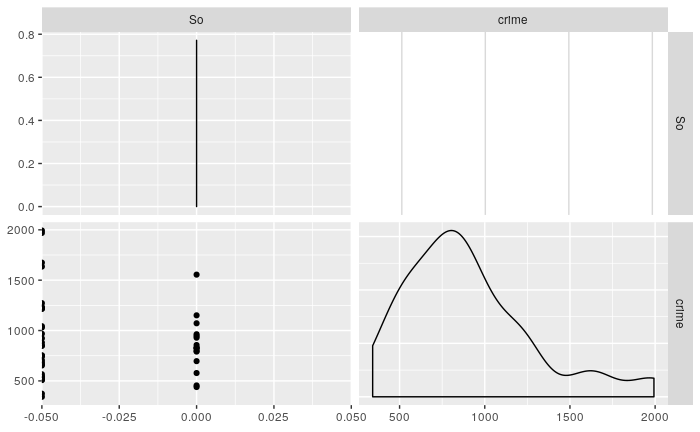

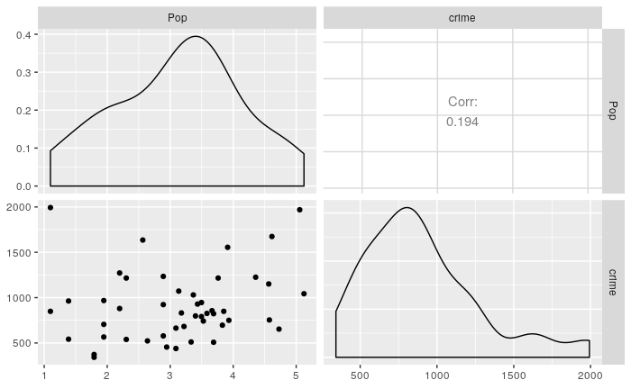

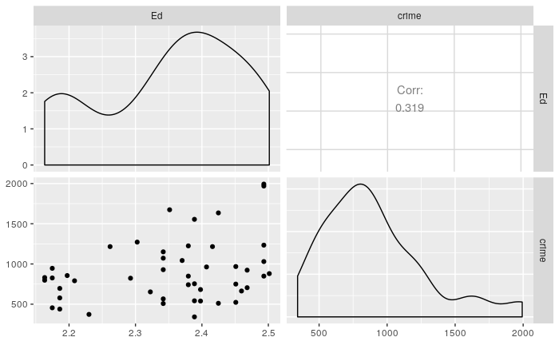

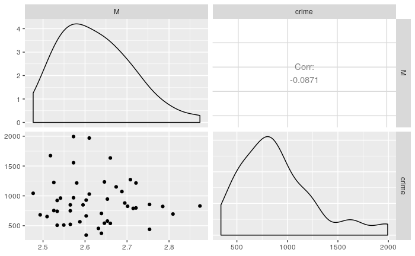

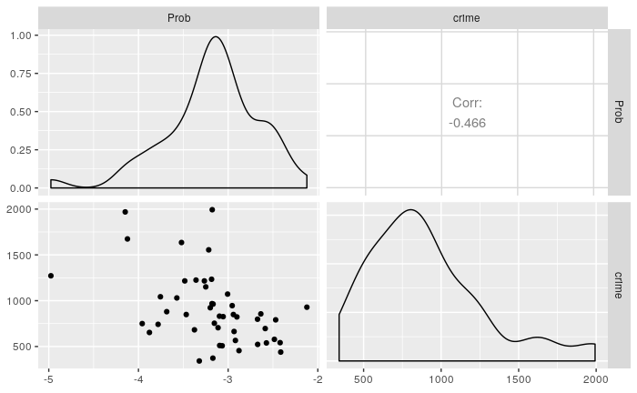

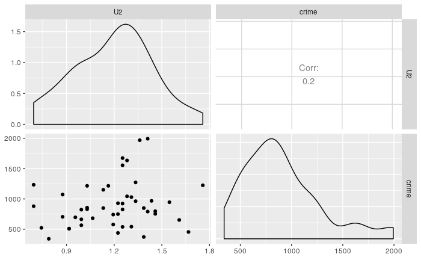

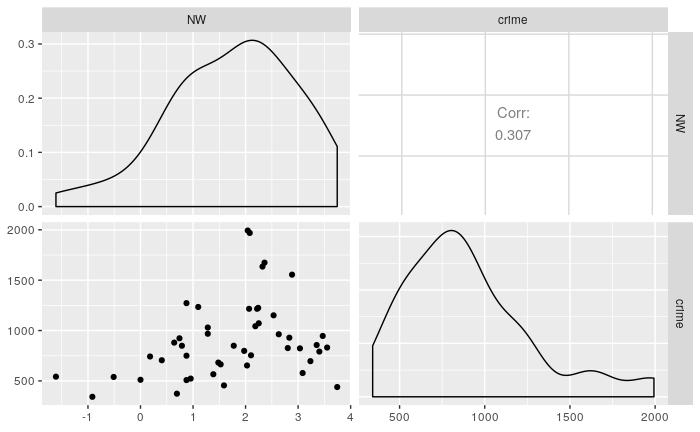

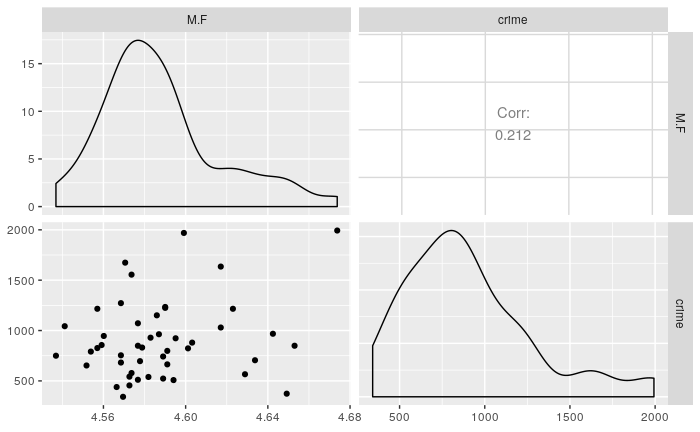

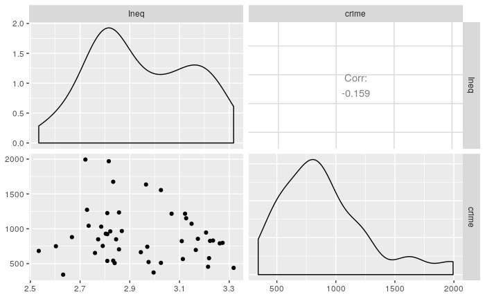

[3 more figures not shown]

```r
log_data = log(data[-16])
log_data['crime'] = data$Crime
for(i in seq(1,15)){
pm = ggpairs(data=log_data,
             columns= c(i,16),

             )
print(pm)
}
```

There doesn’t appear to be any further highly correlated variables in the log transformed data. Let’s build our model and then quantify how good it is. We will actually be building 2 models. One model utilizing all the independent variables at their normal scale, and another model with the independent values scaled and normalized

```r
#model 1 - all independent variables
m1 <- lm(Crime ~ ., data = data)
scaled_data = as.data.frame(scale(data[1:15], center = TRUE, scale = TRUE))
scaled_data['Crime'] = data$Crime
#model 2 - high correlation independent variables
m2 <- lm(Crime ~ ., data = scaled_data)
```

Let’s quantify model 1 first

```r
summary(m1)
```

```
Call:
lm(formula = Crime ~ ., data = data)

Residuals:
    Min      1Q  Median      3Q     Max
-395.74  -98.09   -6.69  112.99  512.67

Coefficients:
              Estimate Std. Error t value Pr(>|t|)
(Intercept) -5.984e+03  1.628e+03  -3.675 0.000893 ***
M            8.783e+01  4.171e+01   2.106 0.043443 *
So          -3.803e+00  1.488e+02  -0.026 0.979765
Ed           1.883e+02  6.209e+01   3.033 0.004861 **
Po1          1.928e+02  1.061e+02   1.817 0.078892 .
Po2         -1.094e+02  1.175e+02  -0.931 0.358830
LF          -6.638e+02  1.470e+03  -0.452 0.654654
M.F          1.741e+01  2.035e+01   0.855 0.398995
Pop         -7.330e-01  1.290e+00  -0.568 0.573845
NW           4.204e+00  6.481e+00   0.649 0.521279
U1          -5.827e+03  4.210e+03  -1.384 0.176238
U2           1.678e+02  8.234e+01   2.038 0.050161 .
Wealth       9.617e-02  1.037e-01   0.928 0.360754
Ineq         7.067e+01  2.272e+01   3.111 0.003983 **
Prob        -4.855e+03  2.272e+03  -2.137 0.040627 *
Time        -3.479e+00  7.165e+00  -0.486 0.630708
---
Signif. codes:  0 ‘***’ 0.001 ‘**’ 0.01 ‘*’ 0.05 ‘.’ 0.1 ‘ ’ 1

Residual standard error: 209.1 on 31 degrees of freedom
Multiple R-squared:  0.8031,    Adjusted R-squared:  0.7078
F-statistic: 8.429 on 15 and 31 DF,  p-value: 3.539e-07
```

***Model 1 Analysis**

The first thing to notice is that the most significant variables are Ed, Ineq, M, Prob, Po1, and U2. This is quantified by each of the variables Pr(>|t|) value and the significance code next to them. The next thing to note is the R-squared and the Adjusted R-squared of 0.8031 and 0.7078 respectively. The R squared value says our model explains 80.3% of the variance in the data, whereas the adjusted R-squared says our model explains 70.8% of the variance in the data. These are extremely good values and signals that we have a significant model or it could mean that we have an overfitted model. This is validated by the overall p-value -of 3.59e-07. This value is greatly below below a p-value of 0.05. Let’s next analyze model2 with the scaled and normalzied independent variables.

```r
summary(m2)
```

```
Call:
lm(formula = Crime ~ ., data = scaled_data)

Residuals:
    Min      1Q  Median      3Q     Max
-395.74  -98.09   -6.69  112.99  512.67

Coefficients:
            Estimate Std. Error t value Pr(>|t|)
(Intercept)  905.085     30.495  29.680  < 2e-16 ***
M            110.382     52.424   2.106  0.04344 *
So            -1.822     71.250  -0.026  0.97977
Ed           210.678     69.458   3.033  0.00486 **
Po1          572.995    315.347   1.817  0.07889 .
Po2         -305.958    328.483  -0.931  0.35883
LF           -26.826     59.394  -0.452  0.65465
M.F           51.293     59.977   0.855  0.39900
Pop          -27.906     49.095  -0.568  0.57385
NW            43.234     66.642   0.649  0.52128
U1          -105.056     75.906  -1.384  0.17624
U2           141.714     69.536   2.038  0.05016 .
Wealth        92.792    100.028   0.928  0.36075
Ineq         281.954     90.630   3.111  0.00398 **
Prob        -110.394     51.667  -2.137  0.04063 *
Time         -24.655     50.780  -0.486  0.63071
---
Signif. codes:  0 ‘***’ 0.001 ‘**’ 0.01 ‘*’ 0.05 ‘.’ 0.1 ‘ ’ 1

Residual standard error: 209.1 on 31 degrees of freedom
Multiple R-squared:  0.8031,    Adjusted R-squared:  0.7078
F-statistic: 8.429 on 15 and 31 DF,  p-value: 3.539e-07
```

***Model 2 Analysis**

The statistics behind model 2 are almost as identical as model one. So we will just use model 1 to predict on the unseen data so as to save a step of scaling the data.

```r
new_data = as.data.frame(t(c(14.0,0,10.0,12.0,15.5,0.640,94.0,150,1.1,0.120,3.6,3200,20.1,0.04,39.0)))
colnames(new_data) = colnames(data)[1:15]
prediction = predict(m1, new_data)
print(prediction)
```

```
       1
155.4349
```

The Crime prediction on the new unseen data is 155